# Experience vs. description based decision-making project: Behavioral data descriptive stats and cleaning

# Set up environment and load in data

```r
library(tidyverse)
library(DT)
library(here)
```

Set theme for plots

```r
theme_set(theme_bw())
```

Specify path for bespoke helper functions

```r
helpers_path = here('helpers/')
```

Read in raw behavioral data

```r
source(paste0(helpers_path,'00_get_behavioral_data.R'))
```

```
## [1] "Beginning reading data in..."
## [1] "Done!"
```

# Descriptive stats

## Number of subjects

How many subjects do we have raw data from?

```r
length(unique(beh_data$subnum))
```

```
## [1] 25
```

How many sessions per subject and trials per session? (There is no subject 21 or 26)

```r
with(beh_data, table(subnum, session))
```

```
##       session
## subnum  1  2  3  4  5
##     01 60 60 60 60 60
##     02 60 60 60 60 60
##     03 60 60 60 60 60
##     04 60 60 60 60 60
##     05 60 60 60 60 60
##     06 60 60 60 60 60
##     07 60 60 60 60 60
##     08 60 60 60 60 60
##     09 60 60 60 60 60
##     10 60 60 60 60 60
##     11 60 60 60 60 60
##     12 60 60 60 60 60
##     13 60 60 60 60 60
##     14 60 60 60 60 60
##     15 60 60 60 60 60
##     16 60 60 60 60 60
##     17 60 60 60 60 60
##     18 60 60 60 60 60
##     19 60 60 60 60 60
##     20 60 60 60 60 60
##     22 60 60 60 60 60
##     23 60 60 60 60 60
##     24 60 60 60 60 60
##     25 60 60 60 60 60
##     27 60 60 60 60 60
```

## Response times

What is the response times distribution?

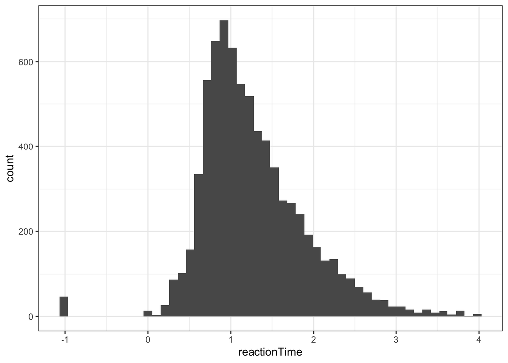

```r
beh_data %>%
  ggplot()+
  geom_histogram(aes(reactionTime), bins=50)
```

How many trials have negative RTs?

```r
nrow(beh_data %>%
  filter(reactionTime < 0))
```

```
## [1] 46
```

How many trials have very fast RTs (RT<.2 sec)?

```r
nrow(beh_data %>%
  filter(reactionTime >0 & reactionTime <.2))
```

```
## [1] 18
```

Are trials with RT<.2 disproportionately from one subject?

There is one subject with more trials with unrealistic RTs (07) but even for this subject the number of trials-to-be-excluded is <5% of their data so not excluding any subjects entirely based on RT data. Will exclude individual trials that have unrealistic RTs.

```r
beh_data %>%
  filter(reactionTime < 0.2) %>%
  count(subnum)
```

```
##    subnum  n
## 1      02  2
## 2      05  5
## 3      07 11
## 4      08  2
## 5      09  3
## 6      10  2
## 7      11  6
## 8      13  1
## 9      14  8
## 10     18  5
## 11     22  2
## 12     23  8
## 13     24  4
## 14     25  4
## 15     27  1
```

## Choices

There are two choice-related columns. `responded` and `choiceLeft`.

The 0’s in `responded` map onto those trials with `reactionTime` < 0.

```r
table(beh_data$responded)
```

```
##
##    0    1
##   46 7454
```

Excluding the non-response trials is `choiceLeft` equally distributed?

```r
beh_data %>%
  filter(responded == 1) %>%
  count(choiceLeft)
```

```
##   choiceLeft    n
## 1          0 3771
## 2          1 3683
```

# Missing values

Are there missing values anywhere?

```r
summary(beh_data)
```

```
##     subnum             session     trialNum     referenceValue referenceProb
##  Length:7500        Min.   :1   Min.   : 1.00   Min.   :1      Min.   :0.5
##  Class :character   1st Qu.:2   1st Qu.:15.75   1st Qu.:1      1st Qu.:0.5
##  Mode  :character   Median :3   Median :30.50   Median :1      Median :0.5
##                     Mean   :3   Mean   :30.50   Mean   :1      Mean   :0.5
##                     3rd Qu.:4   3rd Qu.:45.25   3rd Qu.:1      3rd Qu.:0.5
##                     Max.   :5   Max.   :60.00   Max.   :1      Max.   :0.5
##
##  numRewardedTrials probFractalDraw  lotteryValue     lotteryProb
##  Min.   :35        Min.   :0.000   Min.   : 0.100   Min.   :0.010
##  1st Qu.:35        1st Qu.:0.275   1st Qu.: 0.975   1st Qu.:0.100
##  Median :35        Median :0.500   Median : 2.000   Median :0.275
##  Mean   :35        Mean   :0.500   Mean   : 2.650   Mean   :0.443
##  3rd Qu.:35        3rd Qu.:0.725   3rd Qu.: 2.625   3rd Qu.:0.925
##  Max.   :35        Max.   :1.000   Max.   :10.000   Max.   :1.000
##
##  fractalLeftProb  fractalRightProb  fractalDraw       reactionTime
##  Min.   :0.2501   Min.   :0.2503   Min.   :-1.0000   Min.   :-1.0000
##  1st Qu.:0.3789   1st Qu.:0.3835   1st Qu.: 0.0000   1st Qu.: 0.8527
##  Median :0.5112   Median :0.5079   Median : 1.0000   Median : 1.1539
##  Mean   :0.5037   Mean   :0.5022   Mean   : 0.4977   Mean   : 1.2741
##  3rd Qu.:0.6246   3rd Qu.:0.6197   3rd Qu.: 1.0000   3rd Qu.: 1.6007
##  Max.   :0.7499   Max.   :0.7497   Max.   : 1.0000   Max.   : 3.9977
##                                    NA's   :1
##    responded        choiceLeft          reward        leftFractalReward
##  Min.   :0.0000   Min.   :-1.0000   Min.   : 0.0000   Min.   :-1.0000
##  1st Qu.:1.0000   1st Qu.: 0.0000   1st Qu.: 0.0000   1st Qu.: 0.0000
##  Median :1.0000   Median : 0.0000   Median : 0.7000   Median : 0.0000
##  Mean   :0.9939   Mean   : 0.4849   Mean   : 0.5516   Mean   : 0.4849
##  3rd Qu.:1.0000   3rd Qu.: 1.0000   3rd Qu.: 1.0000   3rd Qu.: 1.0000
##  Max.   :1.0000   Max.   : 1.0000   Max.   :10.0000   Max.   : 1.0000
##                                                       NA's   :1
##  rightFractalReward  totalReward
##  Min.   :-1.0000    Min.   :10.70
##  1st Qu.: 0.0000    1st Qu.:16.90
##  Median : 0.0000    Median :19.00
##  Mean   : 0.4959    Mean   :19.77
##  3rd Qu.: 1.0000    3rd Qu.:22.00
##  Max.   : 1.0000    Max.   :40.60
##  NA's   :1
```

The `NA`s in `fractalDraw`, `leftFractalReward`, `rightFractalReward` are on a non-response trial so they will already be excluded.

```r
beh_data %>%
  filter(is.na(leftFractalReward))
```

```
##   subnum session trialNum referenceValue referenceProb numRewardedTrials
## 1     02       3       60              1           0.5                35
##   probFractalDraw lotteryValue lotteryProb fractalLeftProb fractalRightProb
## 1             0.5            1         0.1       0.6713298        0.3328485
##   fractalDraw reactionTime responded choiceLeft reward leftFractalReward
## 1          NA           -1         0         -1      0                NA
##   rightFractalReward totalReward
## 1                 NA        18.8
```

# Data cleaning steps

- Exclude non-responded trials.
- Exclude trials RTs <.2 seconds.

These will be incorporated in `clean_behavioral_data.R`

What is left after these steps?

```r
clean_beh_data = beh_data %>%
  filter(responded == 1,
         reactionTime > .2)

with(clean_beh_data, table(subnum, session))
```

```
##       session
## subnum  1  2  3  4  5
##     01 60 60 60 60 60
##     02 60 60 58 60 60
##     03 60 60 60 60 60
##     04 60 60 60 60 60
##     05 59 60 58 59 59
##     06 60 60 60 60 60
##     07 60 59 57 55 58
##     08 58 60 60 60 60
##     09 60 59 59 59 60
##     10 60 59 60 59 60
##     11 59 58 59 59 59
##     12 60 60 60 60 60
##     13 59 60 60 60 60
##     14 60 60 60 52 60
##     15 60 60 60 60 60
##     16 60 60 60 60 60
##     17 60 60 60 60 60
##     18 59 59 59 60 58
##     19 60 60 60 60 60
##     20 60 60 60 60 60
##     22 60 60 59 59 60
##     23 60 56 60 56 60
##     24 60 59 58 60 59
##     25 59 60 60 59 58
##     27 60 60 59 60 60
```